# Risk Factor Analysis

## Outcome Variable

**Outcome Variable:** ever_stunted

## Predictor Variables

**Intervention Variable:** nchldlt5

**Adjustment Set:**

- arm
- W_mage
- meducyrs
- feducyrs
- hhwealth_quart
- hfoodsec
- W_mhtcm
- W_nrooms
- W_parity
- impfloor
- impsan
- safeh20
- delta_W_mage
- delta_meducyrs
- delta_feducyrs
- delta_hhwealth_quart
- delta_hfoodsec
- delta_W_mhtcm
- delta_W_nrooms
- delta_W_parity
- delta_impfloor
- delta_impsan
- delta_safeh20

## Stratifying Variables

The analysis was stratified on these variable(s):

- agecat
- studyid
- country

## Data Summary

| agecat | studyid | country | nchldlt5 | ever_stunted | n_cell | n |
| --- | --- | --- | --- | --- | --- | --- |
| 0-24 months | ki1000108-IRC | INDIA | 1 | 0 | 35 | 291 |
| 0-24 months | ki1000108-IRC | INDIA | 1 | 1 | 54 | 291 |
| 0-24 months | ki1000108-IRC | INDIA | 2+ | 0 | 70 | 291 |
| 0-24 months | ki1000108-IRC | INDIA | 2+ | 1 | 132 | 291 |
| 0-24 months | ki1017093b-PROVIDE | BANGLADESH | 1 | 0 | 295 | 524 |
| 0-24 months | ki1017093b-PROVIDE | BANGLADESH | 1 | 1 | 217 | 524 |
| 0-24 months | ki1017093b-PROVIDE | BANGLADESH | 2+ | 0 | 9 | 524 |
| 0-24 months | ki1017093b-PROVIDE | BANGLADESH | 2+ | 1 | 3 | 524 |
| 0-24 months | ki1017093c-NIH-Crypto | BANGLADESH | 1 | 0 | 298 | 547 |
| 0-24 months | ki1017093c-NIH-Crypto | BANGLADESH | 1 | 1 | 243 | 547 |
| 0-24 months | ki1017093c-NIH-Crypto | BANGLADESH | 2+ | 0 | 4 | 547 |
| 0-24 months | ki1017093c-NIH-Crypto | BANGLADESH | 2+ | 1 | 2 | 547 |
| 0-24 months | ki1066203-TanzaniaChild2 | TANZANIA, UNITED REPUBLIC OF | 1 | 0 | 1077 | 1716 |
| 0-24 months | ki1066203-TanzaniaChild2 | TANZANIA, UNITED REPUBLIC OF | 1 | 1 | 560 | 1716 |
| 0-24 months | ki1066203-TanzaniaChild2 | TANZANIA, UNITED REPUBLIC OF | 2+ | 0 | 51 | 1716 |
| 0-24 months | ki1066203-TanzaniaChild2 | TANZANIA, UNITED REPUBLIC OF | 2+ | 1 | 28 | 1716 |
| 0-24 months | ki1112895-iLiNS-Zinc | BURKINA FASO | 1 | 0 | 711 | 1916 |
| 0-24 months | ki1112895-iLiNS-Zinc | BURKINA FASO | 1 | 1 | 362 | 1916 |
| 0-24 months | ki1112895-iLiNS-Zinc | BURKINA FASO | 2+ | 0 | 496 | 1916 |
| 0-24 months | ki1112895-iLiNS-Zinc | BURKINA FASO | 2+ | 1 | 347 | 1916 |
| 0-24 months | ki1148112-LCNI-5 | MALAWI | 1 | 0 | 145 | 454 |
| 0-24 months | ki1148112-LCNI-5 | MALAWI | 1 | 1 | 246 | 454 |
| 0-24 months | ki1148112-LCNI-5 | MALAWI | 2+ | 0 | 24 | 454 |
| 0-24 months | ki1148112-LCNI-5 | MALAWI | 2+ | 1 | 39 | 454 |
| 0-24 months | kiGH5241-JiVitA-3 | BANGLADESH | 1 | 0 | 8565 | 18054 |
| 0-24 months | kiGH5241-JiVitA-3 | BANGLADESH | 1 | 1 | 8849 | 18054 |
| 0-24 months | kiGH5241-JiVitA-3 | BANGLADESH | 2+ | 0 | 348 | 18054 |
| 0-24 months | kiGH5241-JiVitA-3 | BANGLADESH | 2+ | 1 | 292 | 18054 |
| 0-6 months | ki1000108-IRC | INDIA | 1 | 0 | 49 | 291 |
| 0-6 months | ki1000108-IRC | INDIA | 1 | 1 | 40 | 291 |
| 0-6 months | ki1000108-IRC | INDIA | 2+ | 0 | 118 | 291 |
| 0-6 months | ki1000108-IRC | INDIA | 2+ | 1 | 84 | 291 |
| 0-6 months | ki1017093b-PROVIDE | BANGLADESH | 1 | 0 | 384 | 524 |
| 0-6 months | ki1017093b-PROVIDE | BANGLADESH | 1 | 1 | 128 | 524 |
| 0-6 months | ki1017093b-PROVIDE | BANGLADESH | 2+ | 0 | 10 | 524 |
| 0-6 months | ki1017093b-PROVIDE | BANGLADESH | 2+ | 1 | 2 | 524 |
| 0-6 months | ki1017093c-NIH-Crypto | BANGLADESH | 1 | 0 | 386 | 547 |
| 0-6 months | ki1017093c-NIH-Crypto | BANGLADESH | 1 | 1 | 155 | 547 |
| 0-6 months | ki1017093c-NIH-Crypto | BANGLADESH | 2+ | 0 | 6 | 547 |
| 0-6 months | ki1017093c-NIH-Crypto | BANGLADESH | 2+ | 1 | 0 | 547 |
| 0-6 months | ki1066203-TanzaniaChild2 | TANZANIA, UNITED REPUBLIC OF | 1 | 0 | 1311 | 1716 |
| 0-6 months | ki1066203-TanzaniaChild2 | TANZANIA, UNITED REPUBLIC OF | 1 | 1 | 326 | 1716 |
| 0-6 months | ki1066203-TanzaniaChild2 | TANZANIA, UNITED REPUBLIC OF | 2+ | 0 | 66 | 1716 |
| 0-6 months | ki1066203-TanzaniaChild2 | TANZANIA, UNITED REPUBLIC OF | 2+ | 1 | 13 | 1716 |
| 0-6 months | ki1148112-LCNI-5 | MALAWI | 1 | 0 | 81 | 145 |
| 0-6 months | ki1148112-LCNI-5 | MALAWI | 1 | 1 | 41 | 145 |
| 0-6 months | ki1148112-LCNI-5 | MALAWI | 2+ | 0 | 13 | 145 |
| 0-6 months | ki1148112-LCNI-5 | MALAWI | 2+ | 1 | 10 | 145 |
| 0-6 months | kiGH5241-JiVitA-3 | BANGLADESH | 1 | 0 | 9822 | 18002 |
| 0-6 months | kiGH5241-JiVitA-3 | BANGLADESH | 1 | 1 | 7541 | 18002 |
| 0-6 months | kiGH5241-JiVitA-3 | BANGLADESH | 2+ | 0 | 413 | 18002 |
| 0-6 months | kiGH5241-JiVitA-3 | BANGLADESH | 2+ | 1 | 226 | 18002 |
| 6-24 months | ki1000108-IRC | INDIA | 1 | 0 | 35 | 167 |
| 6-24 months | ki1000108-IRC | INDIA | 1 | 1 | 14 | 167 |
| 6-24 months | ki1000108-IRC | INDIA | 2+ | 0 | 70 | 167 |
| 6-24 months | ki1000108-IRC | INDIA | 2+ | 1 | 48 | 167 |
| 6-24 months | ki1017093b-PROVIDE | BANGLADESH | 1 | 0 | 238 | 335 |
| 6-24 months | ki1017093b-PROVIDE | BANGLADESH | 1 | 1 | 89 | 335 |
| 6-24 months | ki1017093b-PROVIDE | BANGLADESH | 2+ | 0 | 7 | 335 |
| 6-24 months | ki1017093b-PROVIDE | BANGLADESH | 2+ | 1 | 1 | 335 |
| 6-24 months | ki1017093c-NIH-Crypto | BANGLADESH | 1 | 0 | 280 | 373 |
| 6-24 months | ki1017093c-NIH-Crypto | BANGLADESH | 1 | 1 | 88 | 373 |
| 6-24 months | ki1017093c-NIH-Crypto | BANGLADESH | 2+ | 0 | 3 | 373 |
| 6-24 months | ki1017093c-NIH-Crypto | BANGLADESH | 2+ | 1 | 2 | 373 |
| 6-24 months | ki1066203-TanzaniaChild2 | TANZANIA, UNITED REPUBLIC OF | 1 | 0 | 858 | 1145 |
| 6-24 months | ki1066203-TanzaniaChild2 | TANZANIA, UNITED REPUBLIC OF | 1 | 1 | 234 | 1145 |
| 6-24 months | ki1066203-TanzaniaChild2 | TANZANIA, UNITED REPUBLIC OF | 2+ | 0 | 38 | 1145 |
| 6-24 months | ki1066203-TanzaniaChild2 | TANZANIA, UNITED REPUBLIC OF | 2+ | 1 | 15 | 1145 |
| 6-24 months | ki1112895-iLiNS-Zinc | BURKINA FASO | 1 | 0 | 711 | 1916 |
| 6-24 months | ki1112895-iLiNS-Zinc | BURKINA FASO | 1 | 1 | 362 | 1916 |
| 6-24 months | ki1112895-iLiNS-Zinc | BURKINA FASO | 2+ | 0 | 496 | 1916 |
| 6-24 months | ki1112895-iLiNS-Zinc | BURKINA FASO | 2+ | 1 | 347 | 1916 |
| 6-24 months | ki1148112-LCNI-5 | MALAWI | 1 | 0 | 138 | 395 |
| 6-24 months | ki1148112-LCNI-5 | MALAWI | 1 | 1 | 205 | 395 |
| 6-24 months | ki1148112-LCNI-5 | MALAWI | 2+ | 0 | 23 | 395 |
| 6-24 months | ki1148112-LCNI-5 | MALAWI | 2+ | 1 | 29 | 395 |
| 6-24 months | kiGH5241-JiVitA-3 | BANGLADESH | 1 | 0 | 5247 | 6804 |
| 6-24 months | kiGH5241-JiVitA-3 | BANGLADESH | 1 | 1 | 1308 | 6804 |
| 6-24 months | kiGH5241-JiVitA-3 | BANGLADESH | 2+ | 0 | 183 | 6804 |
| 6-24 months | kiGH5241-JiVitA-3 | BANGLADESH | 2+ | 1 | 66 | 6804 |

The following strata were considered:

- agecat: 0-24 months, studyid: ki1000108-IRC, country: INDIA
- agecat: 0-24 months, studyid: ki1017093b-PROVIDE, country: BANGLADESH
- agecat: 0-24 months, studyid: ki1017093c-NIH-Crypto, country: BANGLADESH
- agecat: 0-24 months, studyid: ki1066203-TanzaniaChild2, country: TANZANIA, UNITED REPUBLIC OF
- agecat: 0-24 months, studyid: ki1112895-iLiNS-Zinc, country: BURKINA FASO
- agecat: 0-24 months, studyid: ki1148112-LCNI-5, country: MALAWI
- agecat: 0-24 months, studyid: kiGH5241-JiVitA-3, country: BANGLADESH
- agecat: 0-6 months, studyid: ki1000108-IRC, country: INDIA
- agecat: 0-6 months, studyid: ki1017093b-PROVIDE, country: BANGLADESH
- agecat: 0-6 months, studyid: ki1017093c-NIH-Crypto, country: BANGLADESH
- agecat: 0-6 months, studyid: ki1066203-TanzaniaChild2, country: TANZANIA, UNITED REPUBLIC OF
- agecat: 0-6 months, studyid: ki1148112-LCNI-5, country: MALAWI
- agecat: 0-6 months, studyid: kiGH5241-JiVitA-3, country: BANGLADESH
- agecat: 6-24 months, studyid: ki1000108-IRC, country: INDIA
- agecat: 6-24 months, studyid: ki1017093b-PROVIDE, country: BANGLADESH
- agecat: 6-24 months, studyid: ki1017093c-NIH-Crypto, country: BANGLADESH
- agecat: 6-24 months, studyid: ki1066203-TanzaniaChild2, country: TANZANIA, UNITED REPUBLIC OF
- agecat: 6-24 months, studyid: ki1112895-iLiNS-Zinc, country: BURKINA FASO
- agecat: 6-24 months, studyid: ki1148112-LCNI-5, country: MALAWI
- agecat: 6-24 months, studyid: kiGH5241-JiVitA-3, country: BANGLADESH

### Dropped Strata

Some strata were dropped due to rare outcomes:

- agecat: 0-24 months, studyid: ki1017093b-PROVIDE, country: BANGLADESH
- agecat: 0-24 months, studyid: ki1017093c-NIH-Crypto, country: BANGLADESH
- agecat: 0-6 months, studyid: ki1017093b-PROVIDE, country: BANGLADESH
- agecat: 0-6 months, studyid: ki1017093c-NIH-Crypto, country: BANGLADESH
- agecat: 6-24 months, studyid: ki1017093b-PROVIDE, country: BANGLADESH
- agecat: 6-24 months, studyid: ki1017093c-NIH-Crypto, country: BANGLADESH

## Methods Detail

We’re interested in the causal parameters $E[Y_a]$ for all values of $a \in \mathcal{A}$. These parameters represent the mean outcome if, possibly contrary to fact, we intervened to set all units to have $A=a$. Under the randomization and positivity assumptions, these are identified by the statistical parameters $\psi_a=E_W[E_{Y|A,W}(Y|A=a,W)]$. In addition, we’re interested in the mean of $Y$, $E[Y]$ under no intervention (the observed mean). We will estimate these parameters by using SuperLearner to fit the relevant likelihood factors – $E_{Y|A,W}(Y|A=a,W)$ and $p(A=a|W)$, and then updating our likelihood fit using a joint TMLE.

For unadjusted analyses ($W=\{\}$), initial likelihoods were estimated using Lrnr_glm to estimate the simple $E(Y|A)$ and Lrnr_mean to estimate $p(A)$. For adjusted analyses, a small library containing Lrnr_glmnet, Lrnr_xgboost, and Lrnr_mean was used.

Having estimated these parameters, we will then use the delta method to estimate relative risks and attributable risks relative to a prespecified baseline level of $A$.

# Results Detail

## Results Plots

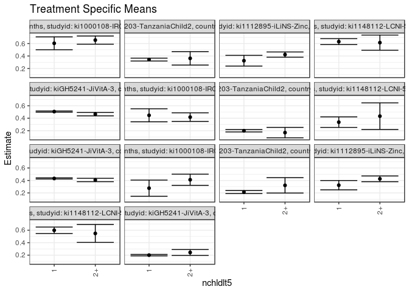

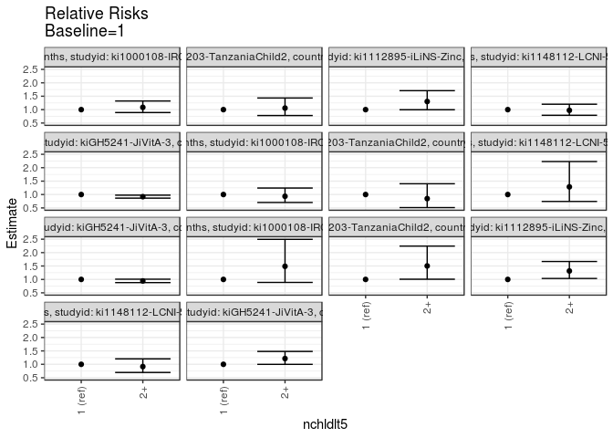

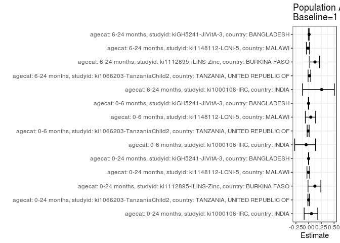

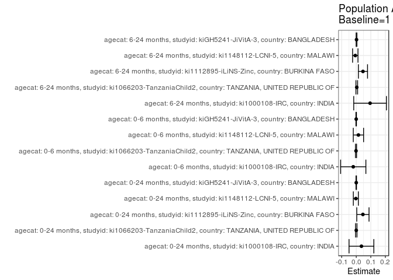

## Results Table

### Parameter: TSM

| agecat | studyid | country | intervention_level | baseline_level | estimate | ci_lower | ci_upper |
| --- | --- | --- | --- | --- | --- | --- | --- |
| 0-24 months | ki1000108-IRC | INDIA | 1 | NA | 0.6035812 | 0.5004145 | 0.7067479 |
| 0-24 months | ki1000108-IRC | INDIA | 2+ | NA | 0.6548292 | 0.5892283 | 0.7204300 |
| 0-24 months | ki1066203-TanzaniaChild2 | TANZANIA, UNITED REPUBLIC OF | 1 | NA | 0.3425979 | 0.3196115 | 0.3655843 |
| 0-24 months | ki1066203-TanzaniaChild2 | TANZANIA, UNITED REPUBLIC OF | 2+ | NA | 0.3623410 | 0.2546873 | 0.4699947 |
| 0-24 months | ki1112895-iLiNS-Zinc | BURKINA FASO | 1 | NA | 0.3243771 | 0.2384247 | 0.4103296 |
| 0-24 months | ki1112895-iLiNS-Zinc | BURKINA FASO | 2+ | NA | 0.4227507 | 0.3807771 | 0.4647242 |
| 0-24 months | ki1148112-LCNI-5 | MALAWI | 1 | NA | 0.6306257 | 0.5828469 | 0.6784044 |
| 0-24 months | ki1148112-LCNI-5 | MALAWI | 2+ | NA | 0.6142000 | 0.4926076 | 0.7357925 |
| 0-24 months | kiGH5241-JiVitA-3 | BANGLADESH | 1 | NA | 0.5063853 | 0.4969178 | 0.5158528 |
| 0-24 months | kiGH5241-JiVitA-3 | BANGLADESH | 2+ | NA | 0.4655349 | 0.4377061 | 0.4933636 |
| 0-6 months | ki1000108-IRC | INDIA | 1 | NA | 0.4467987 | 0.3422272 | 0.5513703 |
| 0-6 months | ki1000108-IRC | INDIA | 2+ | NA | 0.4174010 | 0.3487018 | 0.4861002 |
| 0-6 months | ki1066203-TanzaniaChild2 | TANZANIA, UNITED REPUBLIC OF | 1 | NA | 0.1992771 | 0.1799422 | 0.2186119 |
| 0-6 months | ki1066203-TanzaniaChild2 | TANZANIA, UNITED REPUBLIC OF | 2+ | NA | 0.1690136 | 0.0856539 | 0.2523733 |
| 0-6 months | ki1148112-LCNI-5 | MALAWI | 1 | NA | 0.3367691 | 0.2520428 | 0.4214955 |
| 0-6 months | ki1148112-LCNI-5 | MALAWI | 2+ | NA | 0.4331482 | 0.2199801 | 0.6463164 |
| 0-6 months | kiGH5241-JiVitA-3 | BANGLADESH | 1 | NA | 0.4319598 | 0.4227583 | 0.4411613 |
| 0-6 months | kiGH5241-JiVitA-3 | BANGLADESH | 2+ | NA | 0.4074603 | 0.3805533 | 0.4343673 |
| 6-24 months | ki1000108-IRC | INDIA | 1 | NA | 0.2762342 | 0.1466574 | 0.4058110 |
| 6-24 months | ki1000108-IRC | INDIA | 2+ | NA | 0.4111658 | 0.3216012 | 0.5007303 |
| 6-24 months | ki1066203-TanzaniaChild2 | TANZANIA, UNITED REPUBLIC OF | 1 | NA | 0.2140239 | 0.1896860 | 0.2383618 |
| 6-24 months | ki1066203-TanzaniaChild2 | TANZANIA, UNITED REPUBLIC OF | 2+ | NA | 0.3216587 | 0.1980736 | 0.4452438 |
| 6-24 months | ki1112895-iLiNS-Zinc | BURKINA FASO | 1 | NA | 0.3239184 | 0.2493777 | 0.3984591 |
| 6-24 months | ki1112895-iLiNS-Zinc | BURKINA FASO | 2+ | NA | 0.4260055 | 0.3801550 | 0.4718560 |
| 6-24 months | ki1148112-LCNI-5 | MALAWI | 1 | NA | 0.5990868 | 0.5473388 | 0.6508348 |
| 6-24 months | ki1148112-LCNI-5 | MALAWI | 2+ | NA | 0.5482984 | 0.4046689 | 0.6919279 |
| 6-24 months | kiGH5241-JiVitA-3 | BANGLADESH | 1 | NA | 0.2001032 | 0.1884508 | 0.2117556 |
| 6-24 months | kiGH5241-JiVitA-3 | BANGLADESH | 2+ | NA | 0.2431769 | 0.1959418 | 0.2904121 |

### Parameter: E(Y)

| agecat | studyid | country | intervention_level | baseline_level | estimate | ci_lower | ci_upper |
| --- | --- | --- | --- | --- | --- | --- | --- |
| 0-24 months | ki1000108-IRC | INDIA | NA | NA | 0.6391753 | 0.5839030 | 0.6944475 |
| 0-24 months | ki1066203-TanzaniaChild2 | TANZANIA, UNITED REPUBLIC OF | NA | NA | 0.3426573 | 0.3201957 | 0.3651190 |
| 0-24 months | ki1112895-iLiNS-Zinc | BURKINA FASO | NA | NA | 0.3700418 | 0.3180183 | 0.4220652 |
| 0-24 months | ki1148112-LCNI-5 | MALAWI | NA | NA | 0.6277533 | 0.5832380 | 0.6722686 |
| 0-24 months | kiGH5241-JiVitA-3 | BANGLADESH | NA | NA | 0.5063144 | 0.4970144 | 0.5156143 |
| 0-6 months | ki1000108-IRC | INDIA | NA | NA | 0.4261168 | 0.3692020 | 0.4830316 |
| 0-6 months | ki1066203-TanzaniaChild2 | TANZANIA, UNITED REPUBLIC OF | NA | NA | 0.1975524 | 0.1787088 | 0.2163961 |
| 0-6 months | ki1148112-LCNI-5 | MALAWI | NA | NA | 0.3517241 | 0.2737325 | 0.4297157 |
| 0-6 months | kiGH5241-JiVitA-3 | BANGLADESH | NA | NA | 0.4314521 | 0.4224311 | 0.4404731 |
| 6-24 months | ki1000108-IRC | INDIA | NA | NA | 0.3712575 | 0.2977607 | 0.4447542 |
| 6-24 months | ki1066203-TanzaniaChild2 | TANZANIA, UNITED REPUBLIC OF | NA | NA | 0.2174672 | 0.1935626 | 0.2413719 |
| 6-24 months | ki1112895-iLiNS-Zinc | BURKINA FASO | NA | NA | 0.3700418 | 0.3180183 | 0.4220652 |
| 6-24 months | ki1148112-LCNI-5 | MALAWI | NA | NA | 0.5924051 | 0.5438847 | 0.6409254 |
| 6-24 months | kiGH5241-JiVitA-3 | BANGLADESH | NA | NA | 0.2019400 | 0.1906597 | 0.2132204 |

### Parameter: RR

| agecat | studyid | country | intervention_level | baseline_level | estimate | ci_lower | ci_upper |
| --- | --- | --- | --- | --- | --- | --- | --- |
| 0-24 months | ki1000108-IRC | INDIA | 1 | 1 | 1.0000000 | 1.0000000 | 1.0000000 |
| 0-24 months | ki1000108-IRC | INDIA | 2+ | 1 | 1.0849064 | 0.8909075 | 1.3211495 |
| 0-24 months | ki1066203-TanzaniaChild2 | TANZANIA, UNITED REPUBLIC OF | 1 | 1 | 1.0000000 | 1.0000000 | 1.0000000 |
| 0-24 months | ki1066203-TanzaniaChild2 | TANZANIA, UNITED REPUBLIC OF | 2+ | 1 | 1.0576277 | 0.7804452 | 1.4332541 |
| 0-24 months | ki1112895-iLiNS-Zinc | BURKINA FASO | 1 | 1 | 1.0000000 | 1.0000000 | 1.0000000 |
| 0-24 months | ki1112895-iLiNS-Zinc | BURKINA FASO | 2+ | 1 | 1.3032690 | 0.9953609 | 1.7064265 |
| 0-24 months | ki1148112-LCNI-5 | MALAWI | 1 | 1 | 1.0000000 | 1.0000000 | 1.0000000 |
| 0-24 months | ki1148112-LCNI-5 | MALAWI | 2+ | 1 | 0.9739535 | 0.7892807 | 1.2018353 |
| 0-24 months | kiGH5241-JiVitA-3 | BANGLADESH | 1 | 1 | 1.0000000 | 1.0000000 | 1.0000000 |
| 0-24 months | kiGH5241-JiVitA-3 | BANGLADESH | 2+ | 1 | 0.9193294 | 0.8654237 | 0.9765927 |
| 0-6 months | ki1000108-IRC | INDIA | 1 | 1 | 1.0000000 | 1.0000000 | 1.0000000 |
| 0-6 months | ki1000108-IRC | INDIA | 2+ | 1 | 0.9342037 | 0.7027921 | 1.2418133 |
| 0-6 months | ki1066203-TanzaniaChild2 | TANZANIA, UNITED REPUBLIC OF | 1 | 1 | 1.0000000 | 1.0000000 | 1.0000000 |
| 0-6 months | ki1066203-TanzaniaChild2 | TANZANIA, UNITED REPUBLIC OF | 2+ | 1 | 0.8481338 | 0.5133214 | 1.4013264 |
| 0-6 months | ki1148112-LCNI-5 | MALAWI | 1 | 1 | 1.0000000 | 1.0000000 | 1.0000000 |
| 0-6 months | ki1148112-LCNI-5 | MALAWI | 2+ | 1 | 1.2861876 | 0.7419228 | 2.2297179 |
| 0-6 months | kiGH5241-JiVitA-3 | BANGLADESH | 1 | 1 | 1.0000000 | 1.0000000 | 1.0000000 |
| 0-6 months | kiGH5241-JiVitA-3 | BANGLADESH | 2+ | 1 | 0.9432829 | 0.8817220 | 1.0091420 |
| 6-24 months | ki1000108-IRC | INDIA | 1 | 1 | 1.0000000 | 1.0000000 | 1.0000000 |
| 6-24 months | ki1000108-IRC | INDIA | 2+ | 1 | 1.4884678 | 0.8882207 | 2.4943534 |
| 6-24 months | ki1066203-TanzaniaChild2 | TANZANIA, UNITED REPUBLIC OF | 1 | 1 | 1.0000000 | 1.0000000 | 1.0000000 |
| 6-24 months | ki1066203-TanzaniaChild2 | TANZANIA, UNITED REPUBLIC OF | 2+ | 1 | 1.5029101 | 1.0071269 | 2.2427549 |
| 6-24 months | ki1112895-iLiNS-Zinc | BURKINA FASO | 1 | 1 | 1.0000000 | 1.0000000 | 1.0000000 |
| 6-24 months | ki1112895-iLiNS-Zinc | BURKINA FASO | 2+ | 1 | 1.3151630 | 1.0364089 | 1.6688911 |
| 6-24 months | ki1148112-LCNI-5 | MALAWI | 1 | 1 | 1.0000000 | 1.0000000 | 1.0000000 |
| 6-24 months | ki1148112-LCNI-5 | MALAWI | 2+ | 1 | 0.9152237 | 0.6957206 | 1.2039809 |
| 6-24 months | kiGH5241-JiVitA-3 | BANGLADESH | 1 | 1 | 1.0000000 | 1.0000000 | 1.0000000 |
| 6-24 months | kiGH5241-JiVitA-3 | BANGLADESH | 2+ | 1 | 1.2152576 | 0.9976835 | 1.4802801 |

### Parameter: PAR

| agecat | studyid | country | intervention_level | baseline_level | estimate | ci_lower | ci_upper |
| --- | --- | --- | --- | --- | --- | --- | --- |
| 0-24 months | ki1000108-IRC | INDIA | 1 | NA | 0.0355940 | -0.0496643 | 0.1208523 |
| 0-24 months | ki1066203-TanzaniaChild2 | TANZANIA, UNITED REPUBLIC OF | 1 | NA | 0.0000595 | -0.0048243 | 0.0049433 |
| 0-24 months | ki1112895-iLiNS-Zinc | BURKINA FASO | 1 | NA | 0.0456646 | 0.0035599 | 0.0877693 |
| 0-24 months | ki1148112-LCNI-5 | MALAWI | 1 | NA | -0.0028724 | -0.0201394 | 0.0143947 |
| 0-24 months | kiGH5241-JiVitA-3 | BANGLADESH | 1 | NA | -0.0000709 | -0.0017177 | 0.0015759 |
| 0-6 months | ki1000108-IRC | INDIA | 1 | NA | -0.0206819 | -0.1074448 | 0.0660810 |
| 0-6 months | ki1066203-TanzaniaChild2 | TANZANIA, UNITED REPUBLIC OF | 1 | NA | -0.0017246 | -0.0055857 | 0.0021365 |
| 0-6 months | ki1148112-LCNI-5 | MALAWI | 1 | NA | 0.0149550 | -0.0204332 | 0.0503432 |
| 0-6 months | kiGH5241-JiVitA-3 | BANGLADESH | 1 | NA | -0.0005078 | -0.0021453 | 0.0011298 |
| 6-24 months | ki1000108-IRC | INDIA | 1 | NA | 0.0950233 | -0.0173993 | 0.2074458 |
| 6-24 months | ki1066203-TanzaniaChild2 | TANZANIA, UNITED REPUBLIC OF | 1 | NA | 0.0034433 | -0.0023202 | 0.0092068 |
| 6-24 months | ki1112895-iLiNS-Zinc | BURKINA FASO | 1 | NA | 0.0461233 | 0.0147832 | 0.0774635 |
| 6-24 months | ki1148112-LCNI-5 | MALAWI | 1 | NA | -0.0066817 | -0.0251591 | 0.0117956 |
| 6-24 months | kiGH5241-JiVitA-3 | BANGLADESH | 1 | NA | 0.0018368 | -0.0008910 | 0.0045647 |

### Parameter: PAF

| agecat | studyid | country | intervention_level | baseline_level | estimate | ci_lower | ci_upper |
| --- | --- | --- | --- | --- | --- | --- | --- |
| 0-24 months | ki1000108-IRC | INDIA | 1 | NA | 0.0556874 | -0.0878689 | 0.1802999 |
| 0-24 months | ki1066203-TanzaniaChild2 | TANZANIA, UNITED REPUBLIC OF | 1 | NA | 0.0001735 | -0.0141813 | 0.0143252 |
| 0-24 months | ki1112895-iLiNS-Zinc | BURKINA FASO | 1 | NA | 0.1234040 | -0.0120691 | 0.2407430 |
| 0-24 months | ki1148112-LCNI-5 | MALAWI | 1 | NA | -0.0045756 | -0.0324631 | 0.0225586 |
| 0-24 months | kiGH5241-JiVitA-3 | BANGLADESH | 1 | NA | -0.0001400 | -0.0033979 | 0.0031072 |
| 0-6 months | ki1000108-IRC | INDIA | 1 | NA | -0.0485358 | -0.2732540 | 0.1365216 |
| 0-6 months | ki1066203-TanzaniaChild2 | TANZANIA, UNITED REPUBLIC OF | 1 | NA | -0.0087300 | -0.0284610 | 0.0106224 |
| 0-6 months | ki1148112-LCNI-5 | MALAWI | 1 | NA | 0.0425192 | -0.0637645 | 0.1381838 |
| 0-6 months | kiGH5241-JiVitA-3 | BANGLADESH | 1 | NA | -0.0011769 | -0.0049791 | 0.0026109 |
| 6-24 months | ki1000108-IRC | INDIA | 1 | NA | 0.2559497 | -0.1183788 | 0.5049881 |
| 6-24 months | ki1066203-TanzaniaChild2 | TANZANIA, UNITED REPUBLIC OF | 1 | NA | 0.0158338 | -0.0110079 | 0.0419628 |
| 6-24 months | ki1112895-iLiNS-Zinc | BURKINA FASO | 1 | NA | 0.1246436 | 0.0233901 | 0.2153992 |
| 6-24 months | ki1148112-LCNI-5 | MALAWI | 1 | NA | -0.0112790 | -0.0429789 | 0.0194575 |
| 6-24 months | kiGH5241-JiVitA-3 | BANGLADESH | 1 | NA | 0.0090960 | -0.0045237 | 0.0225309 |